# HW-3-VOOR

## SI370 Winter 2018 -- Assignment 3

Due by: Feb 1 2:30pm.

Submission Instructions: Submit two files on Canvas:

1. A Jupyter Notebook file named HW-3-YOUR_UNIQUE_NAME.ipynb. Please observe the following requirements: This file should show all of the required work, including code, results, visualizations (if any), and necessary comments to your code. Irrelevant code and results should be deleted prior to submission.
2. An html file named HW-3-YOUR_UNIQUE_NAME.html showing the preview of the above IPython Notebook. To create this file, select File -> Download as HTML. We want this in case something breaks when we load your notebook. This will let us see what you saw when you were done.

**Please do NOT compress files. Before generating the html copy, please select Kernel -> Restart & Run All. This step guarantees all your output is consistent with your code.**

# Load everything up that we need

```python
import numpy as np
import pandas as pd
import matplotlib.pyplot as plt
%matplotlib inline
import statsmodels.formula.api as smf
import statsmodels.api as sm
import seaborn as sns
from scipy import stats
sns.set(style='ticks', color_codes=True)
```

```python
# make the Pandas tables a little more readable

from IPython.core.display import HTML
css = open('style-table.css').read() + open('style-notebook.css').read()
HTML('<style>{}</style>'.format(css))
```

# 0. Readings

- [Grus, Joel. "Statistics", Data Science from Scratch. Chapter 5, (2015)](http://proquest.safaribooksonline.com/book/databases/9781491901410/5dot-statistics/statistics_html)
- [Shasha and Wilson, "Statistics is Easy! 2nd ed" Sections 4.1, 4.2, 4.7, 4.8 (2011)](http://www.morganclaypool.com/doi/pdf/10.2200/S00295ED1V01Y201009MAS008)

# 1. Download and Import Data

Download nutritions.csv from the Data folder on Canvas. Import it into your Jupyter Notebook as a Pandas DataFrame.

This is a filtered and cleaned version of USDA nutrition dataset. The original dataset contains detailed measurements of nutritions for more than 8000 food items and more than 200 nutrition measures. This cleaned version contains 2346 food items and 11 nutrition measures.

The dataset contains the following columns:

- **FoodID**: unique ID of the food item
- **GroupID**: unique ID of the food group the item belongs to
- **Food**: the name of the food in verbose format of description
- **Group**: the name of the group
- **Energy**: measure in KCal per 100g of the food item
- **Protein, Fat, Carbohydrate, Ash, Water, Sugars, Fiber**: measures in g per 100g of the food item
- **Calcium, Iron, Sodium**: measure in mg per 100g of the food item

The dataset contains six different food groups:

- Breakfast Cereals
- Snacks
- Beef Products
- Beverages
- Sweets
- Fast Foods

We will ask you to perform aggregation on the group level in this homework.

```python
# Import Data
df_raw = pd.read_csv('nutritions.csv')
df_raw.shape
# df_raw.head()
```

```
(2346, 15)
```

# 2. Cleaning data & Descriptive Statistics

The dataset needs some additional cleaning by you. Perform the following cleaning tasks in sequence:

### 2(a) Remove all rows that have any invalid values (NA). (3 points)

```python
df_clean1 = df_raw[np.isfinite(df_raw['FoodID'])]
df_clean2 = df_clean1[np.isfinite(df_raw['GroupID'])]
df_clean5 = df_clean2[np.isfinite(df_raw['Protein'])]
df_clean6 = df_clean5[np.isfinite(df_raw['Fat'])]
df_clean7 = df_clean6[np.isfinite(df_raw['Carbohydrate'])]
df_clean8 = df_clean7[np.isfinite(df_raw['Ash'])]
df_clean9 = df_clean8[np.isfinite(df_raw['Energy'])]
df_clean10 = df_clean9[np.isfinite(df_raw['Water'])]
df_clean11 = df_clean10[np.isfinite(df_raw['Sugars'])]
df_clean12 = df_clean11[np.isfinite(df_raw['Fiber'])]
df_clean13 = df_clean12[np.isfinite(df_raw['Calcium'])]
df_clean14 = df_clean13[np.isfinite(df_raw['Iron'])]
df_clean15 = df_clean14[np.isfinite(df_raw['Sodium'])]
df_clean15.shape
```

```
(1879, 15)
```

### 2(b) The five basic proximates (Ash, Fat, Protein, Water, and Carbohydrate) should always add up to 100g per food item. Remove the food entries whose five basic proximates do not sum to 100g, with 1g tolerance on both sides. That means, if for a food entry the sum is within (99, 101), then we can keep it. (3 points)

```python
df_clean15['sum'] = df_clean15['Protein']+df_clean15['Ash']+df_clean15['Fat']+df_clean15['Water']+df_clean15['Carbohydrate']
df_clean16 = df_clean15[(df_clean15['sum']>=99)&(df_clean15['sum']<=101)]
# df_clean16 = df_clean15[(df_clean15['sum']<199)]
df_clean16.head()
df_clean16.shape
```

```
(1727, 16)
```

### 2(c) Report the number of entries that are removed at each step. (2 points)

```python
#step 2a)
print('Step 2A removed '+str(df_raw.shape[0]-df_clean15.shape[0])+' entries.')
print('Step 2B removed '+str(df_clean15.shape[0]-df_clean16.shape[0])+' entries.')
```

```
Step 2A removed 467 entries.
Step 2B removed 152 entries.
```

### 2(d) What is the mean Carbohydrates among all food entries? (3 points)

```python
np.mean(df_clean16['Carbohydrate'])
```

```
32.91823972206137
```

### 2(e) What is the mean Proteins for each group (Beverages, Snack, Sweets, etc.)? (3 points)

```python
series1 = df_clean16.groupby('Group')['Protein'].mean()
series1
```

```
Group
Beef Products        24.221713
Beverages             1.856000
Breakfast Cereals     7.959321
Fast Foods           10.780041
Snacks                9.815094
Sweets                4.301043
Name: Protein, dtype: float64
```

### 2(f) Which food has the highest Proteins for each group? What about Energy, Sugar, and Water? (3 points)

```python
highest_proteins = df_clean16.groupby(['Group'])['Protein'].transform(max) == df_clean16['Protein']
df_clean16[highest_proteins]
```

|  | FoodID | GroupID | Food | Group | Protein | Fat | Carbohydrate | Ash | Energy | Water | Sugars | Fiber | Calcium | Iron | Sodium | sum |
| --- | --- | --- | --- | --- | --- | --- | --- | --- | --- | --- | --- | --- | --- | --- | --- | --- |
| 234 | 8471 | 800 | Cereals ready-to-eat, KELLOGG'S, SPECIAL K Pro... | Breakfast Cereals | 33.70 | 9.70 | 47.80 | 5.80 | 349.0 | 3.00 | 6.70 | 17.0 | 135.0 | 28.00 | 380.0 | 100.00 |
| 929 | 14538 | 1400 | Cocoa mix, with aspartame, low calorie, powder... | Beverages | 25.10 | 3.00 | 58.00 | 10.50 | 359.0 | 3.40 | 55.58 | 1.1 | 1440.0 | 4.96 | 653.0 | 100.00 |
| 1021 | 19041 | 2500 | Snacks, pork skins, plain | Snacks | 61.30 | 31.30 | 0.00 | 5.40 | 544.0 | 1.80 | 0.00 | 0.0 | 30.0 | 0.88 | 1818.0 | 99.80 |
| 1144 | 19177 | 1900 | Gelatins, dry powder, unsweetened | Sweets | 85.60 | 0.10 | 0.00 | 1.30 | 335.0 | 13.00 | 0.00 | 0.0 | 55.0 | 1.11 | 196.0 | 100.00 |
| 1757 | 21467 | 2100 | Fast Foods, Fried Chicken, Wing, meat only, sk... | Fast Foods | 28.49 | 11.24 | 3.11 | 2.62 | 228.0 | 54.53 | 0.00 | 0.0 | 29.0 | 0.89 | 651.0 | 99.99 |
| 2179 | 23614 | 1300 | Beef, chuck, arm pot roast, separable lean onl... | Beef Products | 34.72 | 8.37 | 0.00 | 1.03 | 224.0 | 56.39 | 0.00 | 0.0 | 15.0 | 3.04 | 56.0 | 100.51 |

```python
highest_energy = df_clean16.groupby(['Group'])['Energy'].transform(max) == df_clean16['Energy']
df_clean16[highest_energy]
```

|  | FoodID | GroupID | Food | Group | Protein | Fat | Carbohydrate | Ash | Energy | Water | Sugars | Fiber | Calcium | Iron | Sodium | sum |
| --- | --- | --- | --- | --- | --- | --- | --- | --- | --- | --- | --- | --- | --- | --- | --- | --- |
| 24 | 8037 | 800 | Cereals ready-to-eat, granola, homemade | Breakfast Cereals | 14.85 | 24.06 | 53.25 | 2.43 | 489.0 | 5.40 | 20.00 | 9.0 | 78.0 | 4.23 | 25.0 | 99.99 |
| 406 | 13335 | 1300 | Beef, variety meats and by-products, suet, raw | Beef Products | 1.50 | 94.00 | 0.00 | 0.10 | 854.0 | 4.00 | 0.00 | 0.0 | 2.0 | 0.17 | 7.0 | 99.60 |
| 1016 | 19035 | 2500 | Snacks, popcorn, oil-popped, microwave, regula... | Snacks | 7.29 | 43.55 | 45.06 | 2.90 | 583.0 | 1.20 | 0.46 | 8.1 | 4.0 | 1.98 | 1058.0 | 100.00 |
| 1397 | 19904 | 1900 | Chocolate, dark, 70-85% cacao solids | Sweets | 7.79 | 42.63 | 45.90 | 2.32 | 598.0 | 1.37 | 23.99 | 10.9 | 73.0 | 11.90 | 20.0 | 100.01 |
| 1631 | 21325 | 2100 | McDONALD'S, McDONALDLAND Chocolate Chip Cookies | Fast Foods | 5.56 | 22.79 | 66.24 | 1.23 | 480.0 | 4.19 | 33.86 | 2.0 | 34.0 | 3.89 | 293.0 | 100.01 |
| 2321 | 43401 | 1400 | Coffee, dry, powder, with whitener, reduced ca... | Beverages | 1.96 | 29.10 | 59.94 | 2.84 | 509.0 | 6.16 | 59.00 | 0.5 | 18.0 | 0.06 | 0.0 | 100.00 |

```python
highest_sugar = df_clean16.groupby(['Group'])['Sugars'].transform(max) == df_clean16['Sugars']
df_clean16[highest_sugar]
```

|  | FoodID | GroupID | Food | Group | Protein | Fat | Carbohydrate | Ash | Energy | Water | Sugars | Fiber | Calcium | Iron | Sodium | sum |
| --- | --- | --- | --- | --- | --- | --- | --- | --- | --- | --- | --- | --- | --- | --- | --- | --- |
| 45 | 8071 | 800 | Cereals ready-to-eat, KELLOGG, KELLOGG'S HONEY... | Breakfast Cereals | 5.70 | 2.20 | 88.50 | 0.30 | 380.0 | 2.90 | 56.2 | 5.0 | 24.0 | 1.50 | 142.0 | 99.60 |
| 356 | 13000 | 1300 | Beef, grass-fed, strip steaks, lean only, raw | Beef Products | 23.07 | 2.69 | 0.00 | 1.69 | 117.0 | 73.42 | 0.0 | 0.0 | 9.0 | 1.85 | 55.0 | 100.87 |
| 359 | 13019 | 1300 | Beef, retail cuts, separable fat, raw | Beef Products | 8.21 | 70.89 | 0.00 | 0.28 | 674.0 | 20.21 | 0.0 | 0.0 | 26.0 | 0.72 | 26.0 | 99.59 |
| 360 | 13020 | 1300 | Beef, retail cuts, separable fat, cooked | Beef Products | 10.65 | 70.33 | 0.00 | 0.45 | 680.0 | 18.58 | 0.0 | 0.0 | 19.0 | 1.08 | 23.0 | 100.01 |
| 361 | 13023 | 1300 | Beef, brisket, whole, separable lean only, all... | Beef Products | 20.72 | 7.37 | 0.00 | 1.02 | 155.0 | 70.29 | 0.0 | 0.0 | 5.0 | 1.92 | 79.0 | 99.40 |
| 362 | 13047 | 1300 | Beef, grass-fed, ground, raw | Beef Products | 19.42 | 12.73 | 0.00 | 1.71 | 192.0 | 67.13 | 0.0 | 0.0 | 12.0 | 1.99 | 68.0 | 100.99 |
| 363 | 13055 | 1300 | Beef, brisket, flat half, separable lean and f... | Beef Products | 28.97 | 17.37 | 0.00 | 0.93 | 280.0 | 53.39 | 0.0 | 0.0 | 17.0 | 2.40 | 49.0 | 100.66 |
| 364 | 13065 | 1300 | Beef, flank, steak, separable lean and fat, tr... | Beef Products | 21.22 | 8.29 | 0.00 | 1.02 | 165.0 | 69.46 | 0.0 | 0.0 | 27.0 | 1.55 | 54.0 | 99.99 |
| 365 | 13066 | 1300 | Beef, flank, steak, separable lean and fat, tr... | Beef Products | 26.98 | 16.44 | 0.00 | 2.04 | 263.0 | 54.95 | 0.0 | 0.0 | 6.0 | 3.33 | 70.0 | 100.41 |
| 368 | 13069 | 1300 | Beef, flank, steak, separable lean only, trimm... | Beef Products | 28.02 | 13.00 | 0.00 | 2.14 | 237.0 | 57.27 | 0.0 | 0.0 | 6.0 | 3.47 | 72.0 | 100.43 |
| 371 | 13096 | 1300 | Beef, rib, eye, small end (ribs 10-12), separa... | Beef Products | 26.58 | 16.76 | 0.00 | 1.08 | 265.0 | 55.87 | 0.0 | 0.0 | 18.0 | 1.80 | 53.0 | 100.29 |
| 373 | 13098 | 1300 | Beef, rib, eye, small end (ribs 10-12), separa... | Beef Products | 28.88 | 9.01 | 0.00 | 1.17 | 205.0 | 61.30 | 0.0 | 0.0 | 16.0 | 1.98 | 60.0 | 100.36 |
| 375 | 13148 | 1300 | Beef, rib, shortribs, separable lean and fat, ... | Beef Products | 21.57 | 41.98 | 0.00 | 0.74 | 471.0 | 35.72 | 0.0 | 0.0 | 12.0 | 2.31 | 50.0 | 100.01 |
| 377 | 13150 | 1300 | Beef, rib, shortribs, separable lean only, cho... | Beef Products | 30.76 | 18.13 | 0.00 | 0.98 | 295.0 | 50.15 | 0.0 | 0.0 | 11.0 | 3.36 | 58.0 | 100.02 |
| 380 | 13165 | 1300 | Beef, brisket, flat half, separable lean and f... | Beef Products | 32.21 | 9.24 | 0.00 | 1.09 | 221.0 | 58.42 | 0.0 | 0.0 | 17.0 | 2.75 | 52.0 | 100.96 |
| 381 | 13166 | 1300 | USDA Commodity, beef, canned | Beef Products | 20.52 | 17.57 | 0.00 | 1.07 | 246.0 | 61.19 | 0.0 | 0.0 | 10.0 | 2.23 | 187.0 | 100.35 |
| 384 | 13284 | 1300 | Beef, rib eye, small end (ribs 10-12), separab... | Beef Products | 21.17 | 6.57 | 0.00 | 0.93 | 149.0 | 71.33 | 0.0 | 0.0 | 10.0 | 1.94 | 52.0 | 100.00 |
| 385 | 13285 | 1300 | Beef, chuck, under blade pot roast, boneless, ... | Beef Products | 30.54 | 10.46 | 0.00 | 1.39 | 216.0 | 58.22 | 0.0 | 0.0 | 14.0 | 3.19 | 65.0 | 100.61 |
| 386 | 13293 | 1300 | Beef, chuck, under blade pot roast or steak, b... | Beef Products | 21.13 | 6.07 | 0.31 | 1.08 | 140.0 | 71.41 | 0.0 | 0.0 | 12.0 | 2.34 | 81.0 | 100.00 |
| 387 | 13294 | 1300 | Beef, chuck, under blade pot roast or steak, b... | Beef Products | 21.19 | 6.51 | 0.39 | 1.08 | 145.0 | 70.82 | 0.0 | 0.0 | 12.0 | 2.27 | 80.0 | 99.99 |
| 388 | 13317 | 1300 | Beef, ground, patties, frozen, cooked, broiled | Beef Products | 23.05 | 21.83 | 0.00 | 0.90 | 295.0 | 53.91 | 0.0 | 0.0 | 11.0 | 2.42 | 77.0 | 99.69 |
| 389 | 13318 | 1300 | Beef, variety meats and by-products, brain, raw | Beef Products | 10.86 | 10.30 | 1.05 | 1.51 | 143.0 | 76.29 | 0.0 | 0.0 | 43.0 | 2.55 | 126.0 | 100.01 |
| 391 | 13320 | 1300 | Beef, variety meats and by-products, brain, co... | Beef Products | 11.67 | 10.53 | 1.48 | 1.46 | 151.0 | 74.86 | 0.0 | 0.0 | 9.0 | 2.30 | 108.0 | 100.00 |
| 392 | 13321 | 1300 | Beef, variety meats and by-products, heart, raw | Beef Products | 17.72 | 3.94 | 0.14 | 1.10 | 112.0 | 77.11 | 0.0 | 0.0 | 7.0 | 4.31 | 98.0 | 100.01 |
| 393 | 13322 | 1300 | Beef, variety meats and by-products, heart, co... | Beef Products | 28.48 | 4.73 | 0.15 | 0.97 | 165.0 | 65.67 | 0.0 | 0.0 | 5.0 | 6.38 | 59.0 | 100.00 |
| 394 | 13323 | 1300 | Beef, variety meats and by-products, kidneys, raw | Beef Products | 17.40 | 3.09 | 0.29 | 1.33 | 99.0 | 77.89 | 0.0 | 0.0 | 13.0 | 4.60 | 182.0 | 100.00 |
| 395 | 13324 | 1300 | Beef, variety meats and by-products, kidneys, ... | Beef Products | 27.27 | 4.65 | 0.00 | 1.31 | 158.0 | 66.88 | 0.0 | 0.0 | 19.0 | 5.80 | 94.0 | 100.11 |
| 396 | 13325 | 1300 | Beef, variety meats and by-products, liver, raw | Beef Products | 20.36 | 3.63 | 3.89 | 1.31 | 135.0 | 70.81 | 0.0 | 0.0 | 5.0 | 4.90 | 69.0 | 100.00 |
| 397 | 13326 | 1300 | Beef, variety meats and by-products, liver, co... | Beef Products | 29.08 | 5.26 | 5.13 | 1.74 | 191.0 | 58.81 | 0.0 | 0.0 | 6.0 | 6.54 | 79.0 | 100.02 |
| 398 | 13327 | 1300 | Beef, variety meats and by-products, liver, co... | Beef Products | 26.52 | 4.68 | 5.16 | 1.63 | 175.0 | 62.01 | 0.0 | 0.0 | 6.0 | 6.17 | 77.0 | 100.00 |
| ... | ... | ... | ... | ... | ... | ... | ... | ... | ... | ... | ... | ... | ... | ... | ... | ... |
| 2187 | 23622 | 1300 | Beef, round, bottom round, steak, separable le... | Beef Products | 34.22 | 9.02 | 0.00 | 0.98 | 228.0 | 56.44 | 0.0 | 0.0 | 7.0 | 3.01 | 45.0 | 100.66 |
| 2188 | 23623 | 1300 | Beef, rib, small end (ribs 10-12), separable l... | Beef Products | 22.12 | 5.91 | 0.00 | 1.08 | 148.0 | 71.28 | 0.0 | 0.0 | 28.0 | 1.63 | 57.0 | 100.39 |
| 2189 | 23624 | 1300 | Beef, tenderloin, steak, separable lean only, ... | Beef Products | 22.17 | 7.07 | 0.00 | 1.08 | 158.0 | 70.17 | 0.0 | 0.0 | 28.0 | 1.63 | 57.0 | 100.49 |
| 2190 | 23625 | 1300 | Beef, top sirloin, steak, separable lean only,... | Beef Products | 21.91 | 4.62 | 0.00 | 1.09 | 135.0 | 72.51 | 0.0 | 0.0 | 28.0 | 1.63 | 57.0 | 100.13 |
| 2191 | 23626 | 1300 | Beef, rib, small end (ribs 10-12), separable l... | Beef Products | 28.29 | 9.05 | 0.00 | 1.10 | 202.0 | 62.22 | 0.0 | 0.0 | 16.0 | 1.92 | 58.0 | 100.66 |
| 2192 | 23627 | 1300 | Beef, short loin, top loin, steak, separable l... | Beef Products | 22.78 | 6.43 | 0.00 | 1.04 | 155.0 | 70.30 | 0.0 | 0.0 | 29.0 | 1.66 | 58.0 | 100.55 |
| 2193 | 23628 | 1300 | Beef, tenderloin, steak, separable lean only, ... | Beef Products | 29.01 | 9.10 | 0.00 | 1.10 | 206.0 | 61.68 | 0.0 | 0.0 | 16.0 | 1.95 | 59.0 | 100.89 |
| 2194 | 23629 | 1300 | Beef, top sirloin, steak, separable lean only,... | Beef Products | 29.51 | 6.72 | 0.00 | 1.20 | 187.0 | 63.27 | 0.0 | 0.0 | 17.0 | 2.01 | 61.0 | 100.70 |
| 2195 | 23630 | 1300 | Beef, short loin, top loin, steak, separable l... | Beef Products | 29.16 | 8.45 | 0.00 | 1.13 | 201.0 | 61.99 | 0.0 | 0.0 | 16.0 | 1.97 | 60.0 | 100.73 |
| 2196 | 23631 | 1300 | Beef, chuck, arm pot roast, separable lean onl... | Beef Products | 22.26 | 3.32 | 0.00 | 1.00 | 125.0 | 74.12 | 0.0 | 0.0 | 18.0 | 1.86 | 77.0 | 100.70 |
| 2197 | 23632 | 1300 | Beef, brisket, flat half, separable lean only,... | Beef Products | 21.45 | 3.61 | 0.00 | 1.00 | 124.0 | 74.26 | 0.0 | 0.0 | 18.0 | 1.83 | 76.0 | 100.32 |
| 2199 | 23634 | 1300 | Beef, brisket, flat half, separable lean only,... | Beef Products | 33.18 | 5.21 | 0.00 | 1.05 | 189.0 | 61.39 | 0.0 | 0.0 | 17.0 | 2.81 | 55.0 | 100.83 |
| 2200 | 23635 | 1300 | Beef, round, eye of round, roast, separable le... | Beef Products | 22.31 | 2.62 | 0.00 | 1.05 | 119.0 | 73.97 | 0.0 | 0.0 | 22.0 | 1.92 | 62.0 | 99.95 |
| 2201 | 23636 | 1300 | Beef, round, top round, steak, separable lean ... | Beef Products | 23.13 | 3.37 | 0.00 | 1.13 | 129.0 | 72.63 | 0.0 | 0.0 | 22.0 | 1.97 | 64.0 | 100.26 |
| 2202 | 23637 | 1300 | Beef, round, bottom round, roast, separable le... | Beef Products | 22.18 | 3.66 | 0.00 | 1.08 | 128.0 | 73.17 | 0.0 | 0.0 | 21.0 | 1.90 | 62.0 | 100.09 |
| 2204 | 23640 | 1300 | Beef, variety meats and by-products, tripe, co... | Beef Products | 11.71 | 4.05 | 1.99 | 0.60 | 94.0 | 81.65 | 0.0 | 0.0 | 81.0 | 0.66 | 68.0 | 100.00 |
| 2205 | 23646 | 1300 | Beef, bottom sirloin, tri-tip roast, separable... | Beef Products | 21.26 | 5.63 | 0.00 | 1.06 | 142.0 | 72.41 | 0.0 | 0.0 | 23.0 | 1.54 | 54.0 | 100.36 |
| 2206 | 23647 | 1300 | Beef, bottom sirloin, tri-tip roast, separable... | Beef Products | 26.34 | 9.73 | 0.00 | 1.06 | 193.0 | 63.79 | 0.0 | 0.0 | 15.0 | 1.77 | 54.0 | 100.92 |
| 2207 | 23648 | 1300 | Beef, bottom sirloin, tri-tip roast, separable... | Beef Products | 21.17 | 7.06 | 0.00 | 1.02 | 154.0 | 71.33 | 0.0 | 0.0 | 27.0 | 1.54 | 54.0 | 100.58 |
| 2208 | 23649 | 1300 | Beef, bottom sirloin, tri-tip roast, separable... | Beef Products | 27.17 | 6.95 | 0.00 | 1.09 | 179.0 | 65.55 | 0.0 | 0.0 | 20.0 | 1.68 | 58.0 | 100.76 |
| 2209 | 23650 | 1300 | Beef, bottom sirloin, tri-tip roast, separable... | Beef Products | 21.34 | 4.21 | 0.00 | 1.10 | 129.0 | 73.48 | 0.0 | 0.0 | 22.0 | 1.55 | 54.0 | 100.13 |
| 2210 | 23651 | 1300 | Beef, round, tip round, roast, separable lean ... | Beef Products | 21.07 | 3.95 | 0.00 | 1.03 | 126.0 | 74.48 | 0.0 | 0.0 | 18.0 | 1.77 | 54.0 | 100.53 |
| 2211 | 23652 | 1300 | Beef, round, tip round, roast, separable lean ... | Beef Products | 20.76 | 4.55 | 0.00 | 1.02 | 130.0 | 73.98 | 0.0 | 0.0 | 18.0 | 1.92 | 52.0 | 100.31 |
| 2212 | 23653 | 1300 | Beef, round, tip round, roast, separable lean ... | Beef Products | 21.38 | 3.35 | 0.00 | 1.04 | 122.0 | 74.99 | 0.0 | 0.0 | 20.0 | 1.78 | 58.0 | 100.76 |
| 2215 | 23656 | 1300 | Beef, flank, steak, separable lean only, trimm... | Beef Products | 21.57 | 5.47 | 0.00 | 1.02 | 141.0 | 72.08 | 0.0 | 0.0 | 24.0 | 1.57 | 55.0 | 100.14 |
| 2216 | 23657 | 1300 | Beef, flank, steak, separable lean only, trimm... | Beef Products | 21.43 | 5.00 | 0.00 | 0.99 | 137.0 | 72.84 | 0.0 | 0.0 | 21.0 | 1.54 | 53.0 | 100.26 |
| 2217 | 23658 | 1300 | Beef, brisket, flat half, separable lean and f... | Beef Products | 18.12 | 22.15 | 0.12 | 0.82 | 278.0 | 58.80 | 0.0 | 0.0 | 15.0 | 1.68 | 61.0 | 100.01 |
| 2218 | 23659 | 1300 | Beef, brisket, flat half, separable lean and f... | Beef Products | 17.77 | 22.21 | 0.00 | 0.80 | 276.0 | 59.34 | 0.0 | 0.0 | 17.0 | 1.50 | 58.0 | 100.12 |
| 2219 | 23660 | 1300 | Beef, brisket, flat half, separable lean and f... | Beef Products | 28.66 | 19.47 | 0.00 | 0.95 | 298.0 | 51.58 | 0.0 | 0.0 | 16.0 | 2.46 | 46.0 | 100.66 |
| 2259 | 25043 | 2500 | Snacks, candy bits, yogurt covered with vitamin C | Snacks | 0.00 | 7.50 | 86.90 | 1.87 | 415.0 | 3.73 | 65.0 | 0.2 | 500.0 | 0.19 | 75.0 | 100.00 |

612 rows × 16 columns

```python
highest_water = df_clean16.groupby(['Group'])['Water'].transform(max) == df_clean16['Water']
df_clean16[highest_water]
```

|  | FoodID | GroupID | Food | Group | Protein | Fat | Carbohydrate | Ash | Energy | Water | Sugars | Fiber | Calcium | Iron | Sodium | sum |
| --- | --- | --- | --- | --- | --- | --- | --- | --- | --- | --- | --- | --- | --- | --- | --- | --- |
| 259 | 8511 | 800 | Cereals, Malt-o-Meal, plain, prepared with wat... | Breakfast Cereals | 1.36 | 0.15 | 8.72 | 0.26 | 42.0 | 89.51 | 0.13 | 0.5 | 61.0 | 6.43 | 3.0 | 100.00 |
| 411 | 13341 | 1300 | Beef, variety meats and by-products, tripe, raw | Beef Products | 12.07 | 3.69 | 0.00 | 0.55 | 85.0 | 84.16 | 0.00 | 0.0 | 69.0 | 0.59 | 97.0 | 100.47 |
| 940 | 14555 | 1400 | Water, bottled, generic | Beverages | 0.00 | 0.00 | 0.00 | 0.07 | 0.0 | 99.98 | 0.00 | 0.0 | 10.0 | 0.00 | 2.0 | 100.05 |
| 991 | 19002 | 2500 | Snacks, beef jerky, chopped and formed | Snacks | 33.20 | 25.60 | 11.00 | 6.80 | 410.0 | 23.36 | 9.00 | 1.8 | 20.0 | 5.42 | 2081.0 | 99.96 |
| 1680 | 21379 | 2100 | McDONALD'S, Side Salad | Fast Foods | 1.03 | 0.19 | 4.30 | 0.54 | 20.0 | 93.93 | 2.24 | 1.6 | 24.0 | 0.65 | 12.0 | 99.99 |
| 2272 | 42063 | 1900 | Pectin, liquid | Sweets | 0.00 | 0.00 | 2.10 | 1.00 | 11.0 | 96.90 | 0.00 | 2.1 | 0.0 | 0.00 | 0.0 | 100.00 |

### 2(g) Which group has the highest mean Energy? (3 points)

```python
mean_energy = df_clean16.groupby('Group').agg({'Energy':np.mean})
mean_energy.sort_values(by='Energy', ascending=False).head(1)
```

| Group | Energy |
| --- | --- |
| Snacks | 445.735849 |

### 2(h) Create a histogram showing the distribution of Fat for Fast Foods. (make sure to set the axis labels and title the graphic. Hint: set_title and set_xlabel) (5 points)

```
Text(0,0.5,'Count')
```

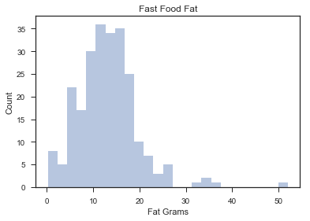

```python
fast_foods = df_clean16[(df_clean16['Group']=='Fast Foods')]
plotz = sns.distplot(fast_foods.Fat, kde=False);
plotz.set_title('Fast Food Fat')
plotz.set_xlabel('Fat Grams')
plotz.set_ylabel('Count')
```

## 3. Correlation and Regression

### (3a) Determine if you need to use a parametric or non-parametric correlation when determining the correlation between Energy and Carbohydrates (among all food categories). Use the appropriate plots to justify your answer. (10 points)

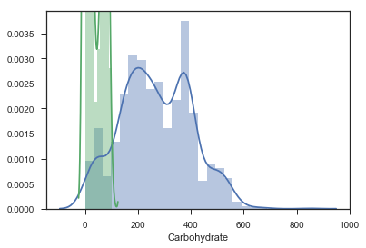

```python
sns.distplot(df_clean16.Energy, kde=True);
sns.distplot(df_clean16.Carbohydrate, kde=True);

#Since these distributions appear to be bimodal and not normal,
#I would use non_parametric correlation.
```

### 3(b) Based on your answer for (a), find the correlation between Energy and Carbohydrate among all food entries. How would you describe it qualitatively? (e.g., High? Low?) (3 points)

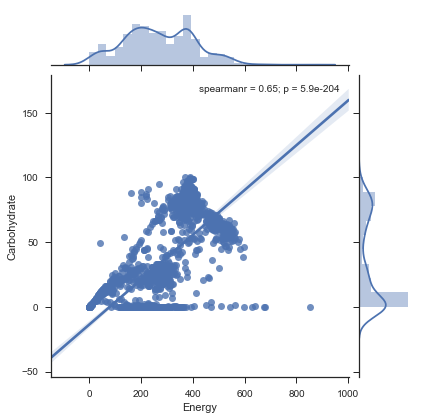

```python
new = df_clean16[['Energy', 'Carbohydrate']].copy()
g = sns.JointGrid(x='Energy',y='Carbohydrate', data=new)
g = g.plot(sns.regplot, sns.distplot)
g = g.annotate(stats.spearmanr)

#spearmanr = .65
#.60-.79 “strong”
```

### 3(c) Generate the correlation matrix between Energy, Carbohydrate, Fat, Protein, Ash, and Water. (4 points)

A Correlation matrix in this case is a 6x6 table (rows and columns are the same: Energy, Carbohydrate, Fat, Protein, Ash, and Water) and the value and the value in the cell is the correlation (1 along the diagonal).

It's ok to pick any correlation method you want here but a non-parametric one might be a "safer" choice since it will work regardless of the distribution. Also, as a hint: this is one line of code, but you may need to go through the dataframe documentation.

```python
data2 = df_clean16[['Protein','Fat','Carbohydrate','Ash','Energy','Water']]
corr = data2.corr(method="pearson")
corr
```

|  | Protein | Fat | Carbohydrate | Ash | Energy | Water |
| --- | --- | --- | --- | --- | --- | --- |
| Protein | 1.000000 | 0.199400 | -0.578083 | -0.024365 | -0.118731 | 0.254182 |
| Fat | 0.199400 | 1.000000 | -0.147644 | 0.024852 | 0.570258 | -0.217245 |
| Carbohydrate | -0.578083 | -0.147644 | 1.000000 | 0.421242 | 0.680828 | -0.893415 |
| Ash | -0.024365 | 0.024852 | 0.421242 | 1.000000 | 0.384925 | -0.515794 |
| Energy | -0.118731 | 0.570258 | 0.680828 | 0.384925 | 1.000000 | -0.913244 |
| Water | 0.254182 | -0.217245 | -0.893415 | -0.515794 | -0.913244 | 1.000000 |

### 3(d) Select only "Beef Products" and create a SPLOM for the same columns above (Energy, Carbohydrates, etc.). From looking at them, which ones seem to have a strong positive or strong negative linear relationship (ones that might be suitable for linear regression)? (3 points)

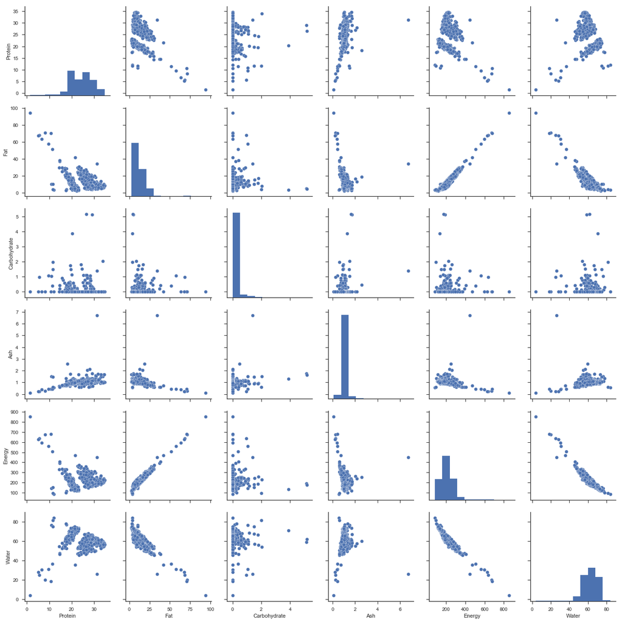

```python
data3 = df_clean16[['Group','Protein','Fat','Carbohydrate','Ash','Energy','Water']]
data3 = data3[(data3['Group']=='Beef Products')]
sns.pairplot(data3,size=3);
# positive linear relationship
# (Energy,Fat) (protein, ash)

# negative linear relationship
# (fat, water) (energy, water)
```

### 3(e) Build a simple regression model for Water and Energy (again Beef Products only). Report the slope/intercept, r-squared, etc. (5 points)

Note that we're cheating a little. Usually we'd check that Water and Energy are normally distributed. Spoiler: they're not really without transformation but we'll just go with it this week.

```python
slope, intercept, r, p, serr = stats.linregress(data3.Water,
                                                data3.Energy)
print("slope=",slope)
print("intercept=",intercept)
print("r value=",r)
print("p value=",p)
print("standard error",serr)
```

```
slope= -8.6895918339
intercept= 756.135579586
r value= -0.952475444634
p value= 1.59150492811e-314
standard error 0.112984722522
```

### 3(f) Calculate the residuals for the model above, then produce the 4 univariate test plots on these residuals (histogram, run sequence, lag plot, and QQ). For each, comment on what you're seeing and what it might mean. (15 points)

Don't worry if you see a "problem," we'll learn how to fix those later.

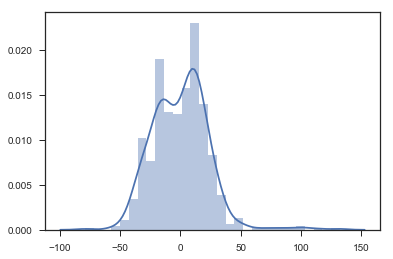

```python
def calcResid(col1,col2):
    slope, intercept, r, p, serr = stats.linregress(col1, col2)
    expected = (slope*col1+intercept)
    residuals = col2 - expected
    return residuals

resid = calcResid(data3.Water,data3.Energy)
#histogram
sns.distplot(resid, kde=True);
```

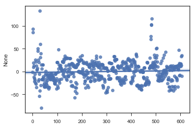

```python
#run sequence
ax = sns.regplot(np.arange(len(resid)),resid,fit_reg=True)
```

```
Text(0.5,0,'y_i')
```

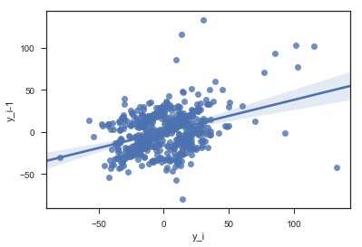

```python
#lag plot
lag = resid.copy()
lag = np.array(lag[:-1])
current = resid[1:]
ax = sns.regplot(current,lag,fit_reg=True)
ax.set_ylabel("y_i-1")
ax.set_xlabel("y_i")
```

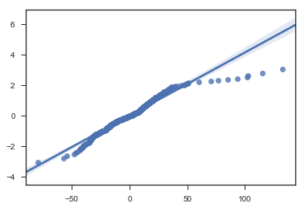

```python
#qq plot
qntls, xr = stats.probplot(resid, fit=False)
sns.regplot(xr,qntls)
```

# References:

[Official site for USDA food nutrients database](http://www.ars.usda.gov/Services/docs.htm?docid=8964) [MySQL version of USDA food nutrients database and preprocessing scripts](https://github.com/mhess126/usda_national_nutrients)

# 4. Get Creative

Find a data set with at least two numeric variables that could potentially be related to each other.

### 4(a). Describe your data. Explain what the variables represent and why you think the variables may be related to each other. Why is this interesting? (10 points)

### 4(b). Using the statistical techniques we covered this week, investigate the relationship between the variables. Be sure to justify the measures you use and interpret your findings. (25 points + up to 10 extra credit points)

This is an open ended question and a reasonable solution will earn full credit. Extra credit will be given for outstanding analysis and/or highly interesting findings.

For this problem, it's fine to use simple regression and interpret the results even if the data breaks some of the assumptions. However, you should report if some of the assumptions are violated.

If you're having a hard time thinking about potential data sets to use, feel free to come to office hours and we will provide suggestions. Keep in mind that the data set does not need to be large or sophisticated. Pick something you are interested in. Have fun!

```python
# The data that I have chosen is economic data for 170 countries.
# Since it contains data regarding infant mortality and literacy,
# I thought it would be interesting to look at their relationship to
# GDP per capita and other factors.
# SOURCE - http://www.sharecsv.com/s/4165c9b03d9fffdef43a3226613ff37c/Countries.csv

# It is interesting because the numbers represent real people and the quality of life that
# is represented by numbers in the dataframe is representative of real struggle that humans face.
df_country_raw = pd.read_csv('Countries.csv')
df_country_raw.shape
df_country_raw.head()
```

|  | Country | Name | GDPPC | Literacy | InfantMortality | Agriculture | Population | NetMigration |
| --- | --- | --- | --- | --- | --- | --- | --- | --- |
| 0 | 1 | Albania | 3965 | 0.987 | 14.0 | 0.227 | 3038594 | -3.3 |
| 1 | 2 | Algeria | 4206 | 0.800 | 27.7 | 0.107 | 39670000 | -0.9 |
| 2 | 3 | Andorra | 42500 | 1.000 | 3.6 | 0.006 | 86165 | 0.0 |
| 3 | 4 | Angola | 4102 | 0.711 | 76.5 | 0.050 | 25020000 | -0.1 |
| 4 | 5 | Anguilla | 8800 | 0.950 | 3.4 | 0.029 | 15000 | 11.9 |

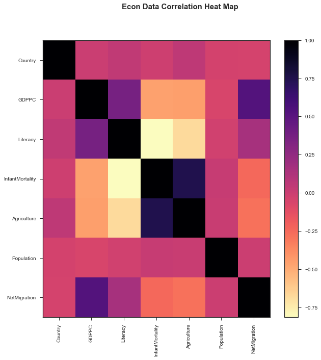

```python
corr = df_country_raw.corr()

# correlation heatmap technique found here
# http://www.marketcalls.in/python/quick-start-guide-compute-correlation-matrix-using-nsepy-pandas-python.html

plt.figure(figsize=(10, 10))
plt.imshow(corr, cmap='magma_r', interpolation='none', aspect='auto')
plt.colorbar()
plt.xticks(range(len(corr)), corr.columns, rotation='vertical')
plt.yticks(range(len(corr)), corr.columns);
plt.suptitle('Econ Data Correlation Heat Map', fontsize=15, fontweight='bold')
plt.show()

# Looks like
# GDP per capita is positively correlated to literacy rate and net migration
# GDP per capita is negatively correlated to infant mortality and agriculture(% of GDP)
# Literacy is negatively correlated to infant mortality and agriculture(% of GDP)
```

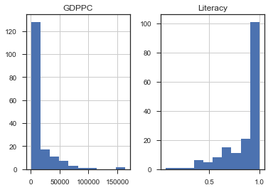

```python
#examine GDPPC and literacy rate
dfc1 = df_country_raw[['GDPPC','Literacy']]
dfc1
dfc1.hist();
#GDPPC and Literacy do not appear to be normal distributions
# so, we will use spearmanr for rank-based non-parametric correlation
```

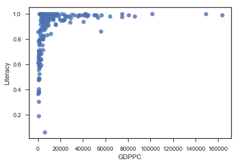

```python
#Plot GDPPC nd Literacy on scatterplot
sns.regplot(data=dfc1,x='GDPPC',y='Literacy',fit_reg=False)
```

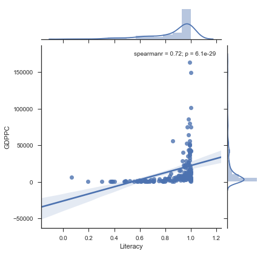

```python
g = sns.JointGrid(x='Literacy',y='GDPPC', data=dfc1)
g = g.plot(sns.regplot, sns.distplot)
g = g.annotate(stats.spearmanr)

# Spearman r correlation coefficient of .72 indicates heavy correlation.
```

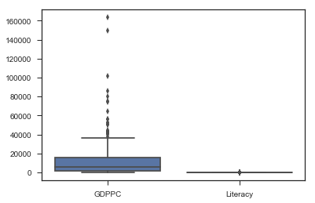

```python
#plot distributions
sns.boxplot(data= dfc1)
```

```python
#linregress
slope, intercept, r, p, serr = stats.linregress(dfc1.GDPPC,
                                                dfc1.Literacy)
print("slope=",slope)
print("intercept=",intercept)
print("r value=",r)
print("p value=",p)
print("standard error",serr)
```

```
slope= 2.91576493794e-06
intercept= 0.808812880298
r value= 0.375366237256
p value= 4.56533538725e-07
standard error 5.55475065053e-07
```

```python
#residuals
expected = (slope*dfc1.GDPPC+intercept)
residuals = dfc1.Literacy - expected
residuals.head()
```

```
0    0.166626
1   -0.021077
2    0.067267
3   -0.109773
4    0.115528
dtype: float64
```

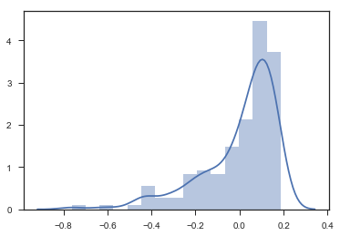

```python
#plot residuals
sns.distplot(residuals, kde=True);
# residuals are not normally distributed so the OLS model doesn't work.
# At this point in the exercise, since the residuals are not normally distributed,
# I'm not sure that I have a technique to offer more clarity.
```